# Risk Factor Analysis

## Outcome Variable

**Outcome Variable:** stunted

## Predictor Variables

**Intervention Variable:** hdlvry

**Adjustment Set:**

- arm
- sex
- W_mage
- meducyrs
- W_nrooms
- brthmon
- W_parity
- impsan
- delta_W_mage
- delta_meducyrs
- delta_W_nrooms
- delta_brthmon
- delta_W_parity
- delta_impsan

## Stratifying Variables

The analysis was stratified on these variable(s):

- agecat
- studyid
- country

## Data Summary

| agecat | studyid | country | hdlvry | stunted | n_cell | n |
| --- | --- | --- | --- | --- | --- | --- |
| 6 months | ki1000108-CMC-V-BCS-2002 | INDIA | 0 | 0 | 249 | 366 |
| 6 months | ki1000108-CMC-V-BCS-2002 | INDIA | 0 | 1 | 109 | 366 |
| 6 months | ki1000108-CMC-V-BCS-2002 | INDIA | 1 | 0 | 7 | 366 |
| 6 months | ki1000108-CMC-V-BCS-2002 | INDIA | 1 | 1 | 1 | 366 |
| 24 months | ki1000108-CMC-V-BCS-2002 | INDIA | 0 | 0 | 102 | 369 |
| 24 months | ki1000108-CMC-V-BCS-2002 | INDIA | 0 | 1 | 259 | 369 |
| 24 months | ki1000108-CMC-V-BCS-2002 | INDIA | 1 | 0 | 3 | 369 |
| 24 months | ki1000108-CMC-V-BCS-2002 | INDIA | 1 | 1 | 5 | 369 |
| Birth | ki1000108-CMC-V-BCS-2002 | INDIA | 0 | 0 | 74 | 90 |
| Birth | ki1000108-CMC-V-BCS-2002 | INDIA | 0 | 1 | 16 | 90 |
| 6 months | ki1000108-IRC | INDIA | 0 | 0 | 303 | 407 |
| 6 months | ki1000108-IRC | INDIA | 0 | 1 | 96 | 407 |
| 6 months | ki1000108-IRC | INDIA | 1 | 0 | 4 | 407 |
| 6 months | ki1000108-IRC | INDIA | 1 | 1 | 4 | 407 |
| 24 months | ki1000108-IRC | INDIA | 0 | 0 | 236 | 409 |
| 24 months | ki1000108-IRC | INDIA | 0 | 1 | 165 | 409 |
| 24 months | ki1000108-IRC | INDIA | 1 | 0 | 3 | 409 |
| 24 months | ki1000108-IRC | INDIA | 1 | 1 | 5 | 409 |
| Birth | ki1000108-IRC | INDIA | 0 | 0 | 337 | 388 |
| Birth | ki1000108-IRC | INDIA | 0 | 1 | 44 | 388 |
| Birth | ki1000108-IRC | INDIA | 1 | 0 | 6 | 388 |
| Birth | ki1000108-IRC | INDIA | 1 | 1 | 1 | 388 |
| 6 months | ki1000109-EE | PAKISTAN | 0 | 0 | 123 | 370 |
| 6 months | ki1000109-EE | PAKISTAN | 0 | 1 | 125 | 370 |
| 6 months | ki1000109-EE | PAKISTAN | 1 | 0 | 55 | 370 |
| 6 months | ki1000109-EE | PAKISTAN | 1 | 1 | 67 | 370 |
| Birth | ki1000109-EE | PAKISTAN | 0 | 0 | 1 | 2 |
| Birth | ki1000109-EE | PAKISTAN | 0 | 1 | 1 | 2 |
| 6 months | ki1000304b-SAS-CompFeed | INDIA | 0 | 0 | 109 | 1091 |
| 6 months | ki1000304b-SAS-CompFeed | INDIA | 0 | 1 | 38 | 1091 |

[output cut: 80 more lines]

The following strata were considered:

- agecat: 24 months, studyid: ki1000108-CMC-V-BCS-2002, country: INDIA
- agecat: 24 months, studyid: ki1000108-IRC, country: INDIA
- agecat: 24 months, studyid: ki1017093b-PROVIDE, country: BANGLADESH
- agecat: 24 months, studyid: ki1017093c-NIH-Crypto, country: BANGLADESH
- agecat: 24 months, studyid: ki1066203-TanzaniaChild2, country: TANZANIA, UNITED REPUBLIC OF
- agecat: 24 months, studyid: ki1113344-GMS-Nepal, country: NEPAL
- agecat: 24 months, studyid: ki1135781-COHORTS, country: INDIA
- agecat: 24 months, studyid: kiGH5241-JiVitA-3, country: BANGLADESH
- agecat: 24 months, studyid: kiGH5241-JiVitA-4, country: BANGLADESH
- agecat: 6 months, studyid: ki1000108-CMC-V-BCS-2002, country: INDIA
- agecat: 6 months, studyid: ki1000108-IRC, country: INDIA
- agecat: 6 months, studyid: ki1000109-EE, country: PAKISTAN
- agecat: 6 months, studyid: ki1000304b-SAS-CompFeed, country: INDIA
- agecat: 6 months, studyid: ki1000304b-SAS-FoodSuppl, country: INDIA
- agecat: 6 months, studyid: ki1017093b-PROVIDE, country: BANGLADESH
- agecat: 6 months, studyid: ki1017093c-NIH-Crypto, country: BANGLADESH
- agecat: 6 months, studyid: ki1066203-TanzaniaChild2, country: TANZANIA, UNITED REPUBLIC OF
- agecat: 6 months, studyid: ki1113344-GMS-Nepal, country: NEPAL
- agecat: 6 months, studyid: ki1135781-COHORTS, country: INDIA
- agecat: 6 months, studyid: kiGH5241-JiVitA-3, country: BANGLADESH
- agecat: 6 months, studyid: kiGH5241-JiVitA-4, country: BANGLADESH
- agecat: Birth, studyid: ki1000108-CMC-V-BCS-2002, country: INDIA
- agecat: Birth, studyid: ki1000108-IRC, country: INDIA
- agecat: Birth, studyid: ki1000109-EE, country: PAKISTAN
- agecat: Birth, studyid: ki1000304b-SAS-CompFeed, country: INDIA
- agecat: Birth, studyid: ki1017093c-NIH-Crypto, country: BANGLADESH
- agecat: Birth, studyid: ki1135781-COHORTS, country: INDIA
- agecat: Birth, studyid: kiGH5241-JiVitA-3, country: BANGLADESH
- agecat: Birth, studyid: kiGH5241-JiVitA-4, country: BANGLADESH

### Dropped Strata

Some strata were dropped due to rare outcomes:

- agecat: 6 months, studyid: ki1000108-CMC-V-BCS-2002, country: INDIA
- agecat: 24 months, studyid: ki1000108-CMC-V-BCS-2002, country: INDIA
- agecat: 6 months, studyid: ki1000108-IRC, country: INDIA
- agecat: 24 months, studyid: ki1000108-IRC, country: INDIA
- agecat: Birth, studyid: ki1000108-IRC, country: INDIA
- agecat: Birth, studyid: ki1000109-EE, country: PAKISTAN
- agecat: Birth, studyid: ki1017093c-NIH-Crypto, country: BANGLADESH
- agecat: 24 months, studyid: ki1066203-TanzaniaChild2, country: TANZANIA, UNITED REPUBLIC OF

## Methods Detail

We’re interested in the causal parameters $E[Y_a]$ for all values of $a \in \mathcal{A}$. These parameters represent the mean outcome if, possibly contrary to fact, we intervened to set all units to have $A=a$. Under the randomization and positivity assumptions, these are identified by the statistical parameters $\psi_a=E_W[E_{Y|A,W}(Y|A=a,W)]$. In addition, we’re interested in the mean of $Y$, $E[Y]$ under no intervention (the observed mean). We will estimate these parameters by using SuperLearner to fit the relevant likelihood factors – $E_{Y|A,W}(Y|A=a,W)$ and $p(A=a|W)$, and then updating our likelihood fit using a joint TMLE.

For unadjusted analyses ($W=\{\}$), initial likelihoods were estimated using Lrnr_glm to estimate the simple $E(Y|A)$ and Lrnr_mean to estimate $p(A)$. For adjusted analyses, a small library containing Lrnr_glmnet, Lrnr_xgboost, and Lrnr_mean was used.

Having estimated these parameters, we will then use the delta method to estimate relative risks and attributable risks relative to a prespecified baseline level of $A$.

[output not shown]

# Results Detail

## Results Plots

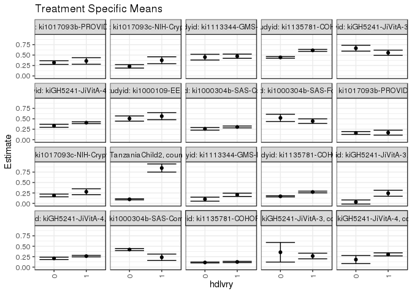

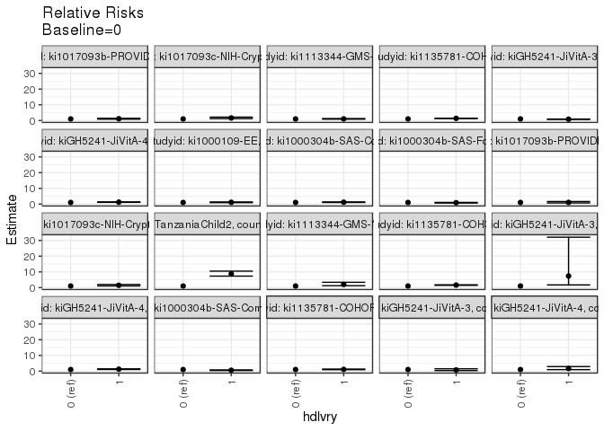

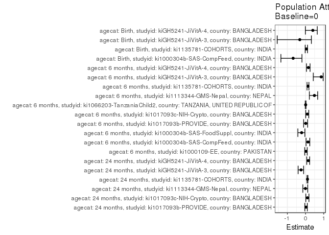

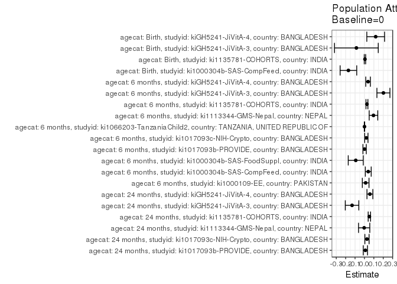

## Results Table

### Parameter: TSM

| agecat | studyid | country | intervention_level | baseline_level | estimate | ci_lower | ci_upper |
| --- | --- | --- | --- | --- | --- | --- | --- |
| Birth | ki1000304b-SAS-CompFeed | INDIA | 0 | NA | 0.4206235 | 0.3955018 | 0.4457453 |
| Birth | ki1000304b-SAS-CompFeed | INDIA | 1 | NA | 0.2354777 | 0.1587392 | 0.3122161 |
| Birth | ki1135781-COHORTS | INDIA | 0 | NA | 0.1110597 | 0.0996152 | 0.1225042 |
| Birth | ki1135781-COHORTS | INDIA | 1 | NA | 0.1237303 | 0.1090172 | 0.1384435 |
| Birth | kiGH5241-JiVitA-3 | BANGLADESH | 0 | NA | 0.3557681 | 0.1205420 | 0.5909942 |
| Birth | kiGH5241-JiVitA-3 | BANGLADESH | 1 | NA | 0.2659982 | 0.1986840 | 0.3333123 |
| Birth | kiGH5241-JiVitA-4 | BANGLADESH | 0 | NA | 0.1801957 | 0.0838319 | 0.2765595 |
| Birth | kiGH5241-JiVitA-4 | BANGLADESH | 1 | NA | 0.3052255 | 0.2685693 | 0.3418818 |
| 6 months | ki1000109-EE | PAKISTAN | 0 | NA | 0.5060044 | 0.4443973 | 0.5676116 |
| 6 months | ki1000109-EE | PAKISTAN | 1 | NA | 0.5629106 | 0.4775823 | 0.6482390 |
| 6 months | ki1000304b-SAS-CompFeed | INDIA | 0 | NA | 0.2590004 | 0.2277608 | 0.2902400 |
| 6 months | ki1000304b-SAS-CompFeed | INDIA | 1 | NA | 0.3047195 | 0.2822971 | 0.3271419 |
| 6 months | ki1000304b-SAS-FoodSuppl | INDIA | 0 | NA | 0.5216206 | 0.4343759 | 0.6088653 |
| 6 months | ki1000304b-SAS-FoodSuppl | INDIA | 1 | NA | 0.4437166 | 0.3890137 | 0.4984196 |
| 6 months | ki1017093b-PROVIDE | BANGLADESH | 0 | NA | 0.1594824 | 0.1250139 | 0.1939509 |
| 6 months | ki1017093b-PROVIDE | BANGLADESH | 1 | NA | 0.1680453 | 0.1087609 | 0.2273297 |
| 6 months | ki1017093c-NIH-Crypto | BANGLADESH | 0 | NA | 0.1896527 | 0.1570586 | 0.2222469 |
| 6 months | ki1017093c-NIH-Crypto | BANGLADESH | 1 | NA | 0.2789561 | 0.2093731 | 0.3485391 |
| 6 months | ki1066203-TanzaniaChild2 | TANZANIA, UNITED REPUBLIC OF | 0 | NA | 0.0968225 | 0.0835120 | 0.1101330 |
| 6 months | ki1066203-TanzaniaChild2 | TANZANIA, UNITED REPUBLIC OF | 1 | NA | 0.8476358 | 0.7501152 | 0.9451564 |
| 6 months | ki1113344-GMS-Nepal | NEPAL | 0 | NA | 0.1012236 | 0.0529160 | 0.1495312 |
| 6 months | ki1113344-GMS-Nepal | NEPAL | 1 | NA | 0.2052156 | 0.1660841 | 0.2443471 |
| 6 months | ki1135781-COHORTS | INDIA | 0 | NA | 0.1691607 | 0.1552429 | 0.1830784 |
| 6 months | ki1135781-COHORTS | INDIA | 1 | NA | 0.2729249 | 0.2532851 | 0.2925648 |
| 6 months | kiGH5241-JiVitA-3 | BANGLADESH | 0 | NA | 0.0330086 | -0.0160393 | 0.0820566 |
| 6 months | kiGH5241-JiVitA-3 | BANGLADESH | 1 | NA | 0.2431684 | 0.1715319 | 0.3148049 |
| 6 months | kiGH5241-JiVitA-4 | BANGLADESH | 0 | NA | 0.2099711 | 0.1816857 | 0.2382566 |
| 6 months | kiGH5241-JiVitA-4 | BANGLADESH | 1 | NA | 0.2630596 | 0.2442814 | 0.2818378 |
| 24 months | ki1017093b-PROVIDE | BANGLADESH | 0 | NA | 0.3194444 | 0.2754384 | 0.3634505 |
| 24 months | ki1017093b-PROVIDE | BANGLADESH | 1 | NA | 0.3586207 | 0.2804910 | 0.4367503 |
| 24 months | ki1017093c-NIH-Crypto | BANGLADESH | 0 | NA | 0.2299596 | 0.1884892 | 0.2714301 |
| 24 months | ki1017093c-NIH-Crypto | BANGLADESH | 1 | NA | 0.3763177 | 0.2939986 | 0.4586368 |
| 24 months | ki1113344-GMS-Nepal | NEPAL | 0 | NA | 0.4505700 | 0.3813479 | 0.5197921 |
| 24 months | ki1113344-GMS-Nepal | NEPAL | 1 | NA | 0.4727338 | 0.4224487 | 0.5230188 |
| 24 months | ki1135781-COHORTS | INDIA | 0 | NA | 0.4440385 | 0.4238528 | 0.4642242 |
| 24 months | ki1135781-COHORTS | INDIA | 1 | NA | 0.6124945 | 0.5881197 | 0.6368692 |
| 24 months | kiGH5241-JiVitA-3 | BANGLADESH | 0 | NA | 0.6645780 | 0.5947061 | 0.7344499 |
| 24 months | kiGH5241-JiVitA-3 | BANGLADESH | 1 | NA | 0.5555120 | 0.4932407 | 0.6177834 |
| 24 months | kiGH5241-JiVitA-4 | BANGLADESH | 0 | NA | 0.3326349 | 0.2961157 | 0.3691541 |
| 24 months | kiGH5241-JiVitA-4 | BANGLADESH | 1 | NA | 0.4066280 | 0.3853758 | 0.4278802 |

### Parameter: E(Y)

| agecat | studyid | country | intervention_level | baseline_level | estimate | ci_lower | ci_upper |
| --- | --- | --- | --- | --- | --- | --- | --- |
| Birth | ki1000304b-SAS-CompFeed | INDIA | NA | NA | 0.2500000 | 0.1698155 | 0.3301845 |
| Birth | ki1135781-COHORTS | INDIA | NA | NA | 0.1165317 | 0.1073518 | 0.1257117 |
| Birth | kiGH5241-JiVitA-3 | BANGLADESH | NA | NA | 0.2700000 | 0.2043793 | 0.3356207 |
| Birth | kiGH5241-JiVitA-4 | BANGLADESH | NA | NA | 0.3000000 | 0.2644043 | 0.3355957 |
| 6 months | ki1000109-EE | PAKISTAN | NA | NA | 0.5189189 | 0.4679396 | 0.5698982 |
| 6 months | ki1000304b-SAS-CompFeed | INDIA | NA | NA | 0.2997250 | 0.2767096 | 0.3227405 |
| 6 months | ki1000304b-SAS-FoodSuppl | INDIA | NA | NA | 0.4289474 | 0.3791199 | 0.4787748 |
| 6 months | ki1017093b-PROVIDE | BANGLADESH | NA | NA | 0.1612350 | 0.1313580 | 0.1911120 |
| 6 months | ki1017093c-NIH-Crypto | BANGLADESH | NA | NA | 0.2097902 | 0.1799252 | 0.2396552 |
| 6 months | ki1066203-TanzaniaChild2 | TANZANIA, UNITED REPUBLIC OF | NA | NA | 0.0973451 | 0.0840860 | 0.1106043 |
| 6 months | ki1113344-GMS-Nepal | NEPAL | NA | NA | 0.1973435 | 0.1633315 | 0.2313554 |
| 6 months | ki1135781-COHORTS | INDIA | NA | NA | 0.1955735 | 0.1842315 | 0.2069155 |
| 6 months | kiGH5241-JiVitA-3 | BANGLADESH | NA | NA | 0.2349398 | 0.1664503 | 0.3034292 |
| 6 months | kiGH5241-JiVitA-4 | BANGLADESH | NA | NA | 0.2486379 | 0.2325647 | 0.2647112 |
| 24 months | ki1017093b-PROVIDE | BANGLADESH | NA | NA | 0.3292894 | 0.2909105 | 0.3676684 |
| 24 months | ki1017093c-NIH-Crypto | BANGLADESH | NA | NA | 0.2568093 | 0.2190047 | 0.2946140 |
| 24 months | ki1113344-GMS-Nepal | NEPAL | NA | NA | 0.4475375 | 0.4023913 | 0.4926837 |
| 24 months | ki1135781-COHORTS | INDIA | NA | NA | 0.4964878 | 0.4800590 | 0.5129165 |
| 24 months | kiGH5241-JiVitA-3 | BANGLADESH | NA | NA | 0.5326460 | 0.4663548 | 0.5989373 |
| 24 months | kiGH5241-JiVitA-4 | BANGLADESH | NA | NA | 0.3907615 | 0.3719765 | 0.4095466 |

### Parameter: RR

| agecat | studyid | country | intervention_level | baseline_level | estimate | ci_lower | ci_upper |
| --- | --- | --- | --- | --- | --- | --- | --- |
| Birth | ki1000304b-SAS-CompFeed | INDIA | 0 | 0 | 1.0000000 | 1.0000000 | 1.000000 |
| Birth | ki1000304b-SAS-CompFeed | INDIA | 1 | 0 | 0.5598300 | 0.4001436 | 0.783243 |
| Birth | ki1135781-COHORTS | INDIA | 0 | 0 | 1.0000000 | 1.0000000 | 1.000000 |
| Birth | ki1135781-COHORTS | INDIA | 1 | 0 | 1.1140881 | 0.9520990 | 1.303638 |
| Birth | kiGH5241-JiVitA-3 | BANGLADESH | 0 | 0 | 1.0000000 | 1.0000000 | 1.000000 |
| Birth | kiGH5241-JiVitA-3 | BANGLADESH | 1 | 0 | 0.7476728 | 0.3724654 | 1.500850 |
| Birth | kiGH5241-JiVitA-4 | BANGLADESH | 0 | 0 | 1.0000000 | 1.0000000 | 1.000000 |
| Birth | kiGH5241-JiVitA-4 | BANGLADESH | 1 | 0 | 1.6938557 | 0.9823056 | 2.920829 |
| 6 months | ki1000109-EE | PAKISTAN | 0 | 0 | 1.0000000 | 1.0000000 | 1.000000 |
| 6 months | ki1000109-EE | PAKISTAN | 1 | 0 | 1.1124619 | 0.9158092 | 1.351342 |
| 6 months | ki1000304b-SAS-CompFeed | INDIA | 0 | 0 | 1.0000000 | 1.0000000 | 1.000000 |
| 6 months | ki1000304b-SAS-CompFeed | INDIA | 1 | 0 | 1.1765214 | 1.0263949 | 1.348606 |
| 6 months | ki1000304b-SAS-FoodSuppl | INDIA | 0 | 0 | 1.0000000 | 1.0000000 | 1.000000 |
| 6 months | ki1000304b-SAS-FoodSuppl | INDIA | 1 | 0 | 0.8506500 | 0.6907639 | 1.047544 |
| 6 months | ki1017093b-PROVIDE | BANGLADESH | 0 | 0 | 1.0000000 | 1.0000000 | 1.000000 |
| 6 months | ki1017093b-PROVIDE | BANGLADESH | 1 | 0 | 1.0536918 | 0.6967510 | 1.593491 |
| 6 months | ki1017093c-NIH-Crypto | BANGLADESH | 0 | 0 | 1.0000000 | 1.0000000 | 1.000000 |
| 6 months | ki1017093c-NIH-Crypto | BANGLADESH | 1 | 0 | 1.4708784 | 1.0868644 | 1.990573 |
| 6 months | ki1066203-TanzaniaChild2 | TANZANIA, UNITED REPUBLIC OF | 0 | 0 | 1.0000000 | 1.0000000 | 1.000000 |
| 6 months | ki1066203-TanzaniaChild2 | TANZANIA, UNITED REPUBLIC OF | 1 | 0 | 8.7545341 | 7.3126650 | 10.480702 |
| 6 months | ki1113344-GMS-Nepal | NEPAL | 0 | 0 | 1.0000000 | 1.0000000 | 1.000000 |
| 6 months | ki1113344-GMS-Nepal | NEPAL | 1 | 0 | 2.0273488 | 1.2122699 | 3.390452 |
| 6 months | ki1135781-COHORTS | INDIA | 0 | 0 | 1.0000000 | 1.0000000 | 1.000000 |
| 6 months | ki1135781-COHORTS | INDIA | 1 | 0 | 1.6134067 | 1.4468510 | 1.799135 |
| 6 months | kiGH5241-JiVitA-3 | BANGLADESH | 0 | 0 | 1.0000000 | 1.0000000 | 1.000000 |
| 6 months | kiGH5241-JiVitA-3 | BANGLADESH | 1 | 0 | 7.3668167 | 1.6920680 | 32.073172 |
| 6 months | kiGH5241-JiVitA-4 | BANGLADESH | 0 | 0 | 1.0000000 | 1.0000000 | 1.000000 |
| 6 months | kiGH5241-JiVitA-4 | BANGLADESH | 1 | 0 | 1.2528371 | 1.0772164 | 1.457090 |
| 24 months | ki1017093b-PROVIDE | BANGLADESH | 0 | 0 | 1.0000000 | 1.0000000 | 1.000000 |
| 24 months | ki1017093b-PROVIDE | BANGLADESH | 1 | 0 | 1.1226387 | 0.8675523 | 1.452728 |
| 24 months | ki1017093c-NIH-Crypto | BANGLADESH | 0 | 0 | 1.0000000 | 1.0000000 | 1.000000 |
| 24 months | ki1017093c-NIH-Crypto | BANGLADESH | 1 | 0 | 1.6364512 | 1.2349903 | 2.168416 |
| 24 months | ki1113344-GMS-Nepal | NEPAL | 0 | 0 | 1.0000000 | 1.0000000 | 1.000000 |
| 24 months | ki1113344-GMS-Nepal | NEPAL | 1 | 0 | 1.0491905 | 0.8734347 | 1.260312 |
| 24 months | ki1135781-COHORTS | INDIA | 0 | 0 | 1.0000000 | 1.0000000 | 1.000000 |
| 24 months | ki1135781-COHORTS | INDIA | 1 | 0 | 1.3793725 | 1.3000176 | 1.463571 |
| 24 months | kiGH5241-JiVitA-3 | BANGLADESH | 0 | 0 | 1.0000000 | 1.0000000 | 1.000000 |
| 24 months | kiGH5241-JiVitA-3 | BANGLADESH | 1 | 0 | 0.8358869 | 0.7267432 | 0.961422 |
| 24 months | kiGH5241-JiVitA-4 | BANGLADESH | 0 | 0 | 1.0000000 | 1.0000000 | 1.000000 |
| 24 months | kiGH5241-JiVitA-4 | BANGLADESH | 1 | 0 | 1.2224453 | 1.0842143 | 1.378300 |

### Parameter: PAR

| agecat | studyid | country | intervention_level | baseline_level | estimate | ci_lower | ci_upper |
| --- | --- | --- | --- | --- | --- | --- | --- |
| Birth | ki1000304b-SAS-CompFeed | INDIA | 0 | NA | -0.1706235 | -0.2590581 | -0.0821890 |
| Birth | ki1135781-COHORTS | INDIA | 0 | NA | 0.0054720 | -0.0020808 | 0.0130248 |
| Birth | kiGH5241-JiVitA-3 | BANGLADESH | 0 | NA | -0.0857681 | -0.3186871 | 0.1471508 |
| Birth | kiGH5241-JiVitA-4 | BANGLADESH | 0 | NA | 0.1198043 | 0.0251867 | 0.2144219 |
| 6 months | ki1000109-EE | PAKISTAN | 0 | NA | 0.0129145 | -0.0225870 | 0.0484160 |
| 6 months | ki1000304b-SAS-CompFeed | INDIA | 0 | NA | 0.0407246 | 0.0094955 | 0.0719537 |
| 6 months | ki1000304b-SAS-FoodSuppl | INDIA | 0 | NA | -0.0926733 | -0.1725381 | -0.0128085 |
| 6 months | ki1017093b-PROVIDE | BANGLADESH | 0 | NA | 0.0017526 | -0.0159671 | 0.0194722 |
| 6 months | ki1017093c-NIH-Crypto | BANGLADESH | 0 | NA | 0.0201375 | 0.0026442 | 0.0376308 |
| 6 months | ki1066203-TanzaniaChild2 | TANZANIA, UNITED REPUBLIC OF | 0 | NA | 0.0005226 | -0.0016467 | 0.0026920 |
| 6 months | ki1113344-GMS-Nepal | NEPAL | 0 | NA | 0.0961198 | 0.0504119 | 0.1418278 |
| 6 months | ki1135781-COHORTS | INDIA | 0 | NA | 0.0264129 | 0.0163319 | 0.0364939 |
| 6 months | kiGH5241-JiVitA-3 | BANGLADESH | 0 | NA | 0.2019311 | 0.1327064 | 0.2711559 |
| 6 months | kiGH5241-JiVitA-4 | BANGLADESH | 0 | NA | 0.0386668 | 0.0139359 | 0.0633978 |
| 24 months | ki1017093b-PROVIDE | BANGLADESH | 0 | NA | 0.0098450 | -0.0127319 | 0.0324218 |
| 24 months | ki1017093c-NIH-Crypto | BANGLADESH | 0 | NA | 0.0268497 | 0.0044931 | 0.0492064 |
| 24 months | ki1113344-GMS-Nepal | NEPAL | 0 | NA | -0.0030325 | -0.0629813 | 0.0569163 |
| 24 months | ki1135781-COHORTS | INDIA | 0 | NA | 0.0524493 | 0.0398157 | 0.0650830 |
| 24 months | kiGH5241-JiVitA-3 | BANGLADESH | 0 | NA | -0.1319319 | -0.2039672 | -0.0598967 |
| 24 months | kiGH5241-JiVitA-4 | BANGLADESH | 0 | NA | 0.0581266 | 0.0269397 | 0.0893135 |

### Parameter: PAF

| agecat | studyid | country | intervention_level | baseline_level | estimate | ci_lower | ci_upper |
| --- | --- | --- | --- | --- | --- | --- | --- |
| Birth | ki1000304b-SAS-CompFeed | INDIA | 0 | NA | -0.6824941 | -1.3570793 | -0.2009721 |
| Birth | ki1135781-COHORTS | INDIA | 0 | NA | 0.0469573 | -0.0199284 | 0.1094567 |
| Birth | kiGH5241-JiVitA-3 | BANGLADESH | 0 | NA | -0.3176598 | -1.5581827 | 0.3213045 |
| Birth | kiGH5241-JiVitA-4 | BANGLADESH | 0 | NA | 0.3993476 | -0.0103654 | 0.6429180 |
| 6 months | ki1000109-EE | PAKISTAN | 0 | NA | 0.0248873 | -0.0459848 | 0.0909574 |
| 6 months | ki1000304b-SAS-CompFeed | INDIA | 0 | NA | 0.1358733 | 0.0289358 | 0.2310343 |
| 6 months | ki1000304b-SAS-FoodSuppl | INDIA | 0 | NA | -0.2160481 | -0.4237273 | -0.0386631 |
| 6 months | ki1017093b-PROVIDE | BANGLADESH | 0 | NA | 0.0108698 | -0.1053488 | 0.1148689 |
| 6 months | ki1017093c-NIH-Crypto | BANGLADESH | 0 | NA | 0.0959886 | 0.0093561 | 0.1750450 |
| 6 months | ki1066203-TanzaniaChild2 | TANZANIA, UNITED REPUBLIC OF | 0 | NA | 0.0053689 | -0.0171362 | 0.0273762 |
| 6 months | ki1113344-GMS-Nepal | NEPAL | 0 | NA | 0.4870688 | 0.2092845 | 0.6672654 |
| 6 months | ki1135781-COHORTS | INDIA | 0 | NA | 0.1350534 | 0.0826426 | 0.1844699 |
| 6 months | kiGH5241-JiVitA-3 | BANGLADESH | 0 | NA | 0.8595018 | 0.4229598 | 0.9657914 |
| 6 months | kiGH5241-JiVitA-4 | BANGLADESH | 0 | NA | 0.1555145 | 0.0503778 | 0.2490111 |
| 24 months | ki1017093b-PROVIDE | BANGLADESH | 0 | NA | 0.0298977 | -0.0411411 | 0.0960893 |
| 24 months | ki1017093c-NIH-Crypto | BANGLADESH | 0 | NA | 0.1045512 | 0.0137251 | 0.1870130 |
| 24 months | ki1113344-GMS-Nepal | NEPAL | 0 | NA | -0.0067760 | -0.1501718 | 0.1187422 |
| 24 months | ki1135781-COHORTS | INDIA | 0 | NA | 0.1056407 | 0.0797732 | 0.1307810 |
| 24 months | kiGH5241-JiVitA-3 | BANGLADESH | 0 | NA | -0.2476916 | -0.4102309 | -0.1038861 |
| 24 months | kiGH5241-JiVitA-4 | BANGLADESH | 0 | NA | 0.1487522 | 0.0646749 | 0.2252717 |